# Powerlifting - Logistic Regression Model

Andrés De Freitas Carmona

2025-01-06

# Taking the Proportions Model One Step Further

The initial hypothesis of the project was rejected in the previous document. However, the Proportions Model opens new opportunities to research about the sport. The next question to be asked is: what can the Proportions Model, which defines the movement specialty of athletes, offer to better help the understanding of *Powerlifting*?

All sports, especially practiced at high performance levels, have the same objective: host competitions with competitive athletes that reach the podiums with high performances. The ultimate goal, as an athlete, is to be in the podium of a competition.

In this section, a machine learning model will be proposed to determine if the available data is capable of correctly predicting if an athlete ends up in the podium or not.

# 1. Libraries

```r
library(readr)
library(dplyr)
library(lubridate)
library(ggplot2)
library(tidyr)
library(caTools)
library(caret)
library(glmnet)
library(pROC)
library(PRROC)
library(ROCR)
library(reshape2)
library(cowplot)
```

# 2. Data loading

The data was downloaded from openpowerlifting.org on January 4th, 2025.

```r
openpowerliftingdata <- read_csv("C:/Users/andre/OneDrive/Escritorio/TFM/openpowerliftingdata3.csv")
```

# 3. Data division

1. Data is split in female and male data sets, allowing for better data management.
2. Data has been filtered for the International Powerlifting Federation (IPF), one of the most important federations in the sport.

```r
ipf_male_data <- openpowerliftingdata %>% filter(Federation == "IPF", Sex == "M")
ipf_female_data <- openpowerliftingdata %>% filter(Federation == "IPF", Sex == "F")
```

# 4. Data cleaning

### 4.1. Convert variables to factors.

```r
ipf_male_data <- ipf_male_data %>%
  mutate(
    WeightClassKg = as.factor(WeightClassKg),
    Division = as.factor(Division),
    Equipment = as.factor(Equipment)
  )

ipf_female_data <- ipf_female_data %>%
  mutate(
    WeightClassKg = as.factor(WeightClassKg),
    Division = as.factor(Division),
    Equipment = as.factor(Equipment)
  )
```

### 4.2. Classifying competitions by movements.

Not all competitions host all three movements in their events. There are either one or three movement competitions.

```r
# Male

ipf_male_data <- ipf_male_data %>%
  mutate(
    BooleanSquat = ifelse(
      is.na(Bench1Kg) & is.na(Bench2Kg) & is.na(Bench3Kg) & is.na(Bench4Kg) & is.na(Best3BenchKg) &
        is.na(Deadlift1Kg) & is.na(Deadlift2Kg) & is.na(Deadlift3Kg) & is.na(Deadlift4Kg) & is.na(Best3DeadliftKg) &
        (!is.na(Squat1Kg) | !is.na(Squat2Kg) | !is.na(Squat3Kg) | !is.na(Squat4Kg) | !is.na(Best3SquatKg)),
      1, 0
    ),
    BooleanBench = ifelse(
      is.na(Squat1Kg) & is.na(Squat2Kg) & is.na(Squat3Kg) & is.na(Squat4Kg) & is.na(Best3SquatKg) &
        is.na(Deadlift1Kg) & is.na(Deadlift2Kg) & is.na(Deadlift3Kg) & is.na(Deadlift4Kg) & is.na(Best3DeadliftKg) &
        (!is.na(Bench1Kg) | !is.na(Bench2Kg) | !is.na(Bench3Kg) | !is.na(Bench4Kg) | !is.na(Best3BenchKg)),
      1, 0
    ),
    BooleanDeadlift = ifelse(
      is.na(Squat1Kg) & is.na(Squat2Kg) & is.na(Squat3Kg) & is.na(Squat4Kg) & is.na(Best3SquatKg) &
        is.na(Bench1Kg) & is.na(Bench2Kg) & is.na(Bench3Kg) & is.na(Bench4Kg) & is.na(Best3BenchKg) &
        (!is.na(Deadlift1Kg) | !is.na(Deadlift2Kg) | !is.na(Deadlift3Kg) | !is.na(Deadlift4Kg) | !is.na(Best3DeadliftKg)),
      1, 0
    ),
    BooleanDisq = ifelse(
      (is.na(Squat1Kg) & is.na(Squat2Kg) & is.na(Squat3Kg) & is.na(Squat4Kg) & is.na(Best3SquatKg) &
         is.na(Bench1Kg) & is.na(Bench2Kg) & is.na(Bench3Kg) & is.na(Bench4Kg) & is.na(Best3BenchKg) &
         is.na(Deadlift1Kg) & is.na(Deadlift2Kg) & is.na(Deadlift3Kg) & is.na(Deadlift4Kg) & is.na(Best3DeadliftKg)) |
        Place == "DQ",
      1, 0
    )
  )

# Female

ipf_female_data <- ipf_female_data %>%
  mutate(
    BooleanSquat = ifelse(
      is.na(Bench1Kg) & is.na(Bench2Kg) & is.na(Bench3Kg) & is.na(Bench4Kg) & is.na(Best3BenchKg) &
        is.na(Deadlift1Kg) & is.na(Deadlift2Kg) & is.na(Deadlift3Kg) & is.na(Deadlift4Kg) & is.na(Best3DeadliftKg) &
        (!is.na(Squat1Kg) | !is.na(Squat2Kg) | !is.na(Squat3Kg) | !is.na(Squat4Kg) | !is.na(Best3SquatKg)),
      1, 0
    ),
    BooleanBench = ifelse(
      is.na(Squat1Kg) & is.na(Squat2Kg) & is.na(Squat3Kg) & is.na(Squat4Kg) & is.na(Best3SquatKg) &
        is.na(Deadlift1Kg) & is.na(Deadlift2Kg) & is.na(Deadlift3Kg) & is.na(Deadlift4Kg) & is.na(Best3DeadliftKg) &
        (!is.na(Bench1Kg) | !is.na(Bench2Kg) | !is.na(Bench3Kg) | !is.na(Bench4Kg) | !is.na(Best3BenchKg)),
      1, 0
    ),
    BooleanDeadlift = ifelse(
      is.na(Squat1Kg) & is.na(Squat2Kg) & is.na(Squat3Kg) & is.na(Squat4Kg) & is.na(Best3SquatKg) &
        is.na(Bench1Kg) & is.na(Bench2Kg) & is.na(Bench3Kg) & is.na(Bench4Kg) & is.na(Best3BenchKg) &
        (!is.na(Deadlift1Kg) | !is.na(Deadlift2Kg) | !is.na(Deadlift3Kg) | !is.na(Deadlift4Kg) | !is.na(Best3DeadliftKg)),
      1, 0
    ),
    BooleanDisq = ifelse(
      (is.na(Squat1Kg) & is.na(Squat2Kg) & is.na(Squat3Kg) & is.na(Squat4Kg) & is.na(Best3SquatKg) &
         is.na(Bench1Kg) & is.na(Bench2Kg) & is.na(Bench3Kg) & is.na(Bench4Kg) & is.na(Best3BenchKg) &
         is.na(Deadlift1Kg) & is.na(Deadlift2Kg) & is.na(Deadlift3Kg) & is.na(Deadlift4Kg) & is.na(Best3DeadliftKg)) |
        Place == "DQ",
      1, 0
    )
  )
```

### 4.3. Removing competitions with only one movement.

An important step in the data cleaning process of this project is the removal of competitions that do not execute the three movements. This criterion is a fundamental principle of the project and will be discussed later.

```r
# Male

ipf_male_data_clean <- ipf_male_data %>%
  filter(
    (BooleanSquat + BooleanBench + BooleanDeadlift != 1) &
      (BooleanDisq == 0)
  )

# Female

ipf_female_data_clean <- ipf_female_data %>%
  filter(
    (BooleanSquat + BooleanBench + BooleanDeadlift != 1) &
      (BooleanDisq == 0)
  )
```

### 4.4. Removing boolean variables created, since they no longer serve any purpose.

```r
ipf_male_data_clean <- ipf_male_data_clean %>%
  select(-BooleanSquat, -BooleanBench, -BooleanDeadlift, -BooleanDisq)

ipf_female_data_clean <- ipf_female_data_clean %>%
  select(-BooleanSquat, -BooleanBench, -BooleanDeadlift, -BooleanDisq)
```

### 4.5. Removing old divisions.

**Divisions** evolved through time. Nowadays, the IPF ceased the use of the following.

```r
excluded_divisions <- c("Light", "Middle", "Heavy", "Super", "SOI", "SuperHeavy")

ipf_male_data_clean <- ipf_male_data_clean %>%
  filter(!Division %in% excluded_divisions)

ipf_female_data_clean <- ipf_female_data_clean %>%
  filter(!Division %in% excluded_divisions)
```

### 4.6. Removing disqualified athletes.

```r
excluded_places <- c("DD", "DQ", "G")

ipf_male_data_clean <- ipf_male_data_clean %>%
  filter(!Place %in% excluded_places)

ipf_female_data_clean <- ipf_female_data_clean %>%
  filter(!Place %in% excluded_places)
```

### 4.7. Filter 82.5+ female weight class, as it complicates calculations and code.

```r
ipf_female_data_clean <- ipf_female_data_clean %>%
  filter(!WeightClassKg == "82.5+")
```

# 5. Proportions Model

### 5.1. We create new variables to calculate the proportions of each movement respect to the total.

```r
ipf_male_data_clean <- ipf_male_data_clean %>%
  mutate(
    SquatProportion = Best3SquatKg / TotalKg,
    BenchPressProportion = Best3BenchKg / TotalKg,
    DeadliftProportion = Best3DeadliftKg / TotalKg
  )


ipf_female_data_clean <- ipf_female_data_clean %>%
  mutate(
    SquatProportion = Best3SquatKg / TotalKg,
    BenchPressProportion = Best3BenchKg / TotalKg,
    DeadliftProportion = Best3DeadliftKg / TotalKg
  )
```

### 5.2. Proportions must be normalized, since the sum of averages can be different from 1.

```r
# Normalized proportions

# Male

ipf_male_data_clean <- ipf_male_data_clean %>%
  mutate(
    SquatProportion = ifelse(is.na(SquatProportion), mean(SquatProportion, na.rm = TRUE), SquatProportion),
    BenchPressProportion = ifelse(is.na(BenchPressProportion), mean(BenchPressProportion, na.rm = TRUE), BenchPressProportion),
    DeadliftProportion = ifelse(is.na(DeadliftProportion), mean(DeadliftProportion, na.rm = TRUE), DeadliftProportion)
  ) %>%
  mutate(
    TotalProportion = SquatProportion + BenchPressProportion + DeadliftProportion,
    SquatProportion = SquatProportion / TotalProportion,
    BenchPressProportion = BenchPressProportion / TotalProportion,
    DeadliftProportion = DeadliftProportion / TotalProportion
  ) %>%
  select(-TotalProportion)


# Female

ipf_female_data_clean <- ipf_female_data_clean %>%
  mutate(
    SquatProportion = ifelse(is.na(SquatProportion), mean(SquatProportion, na.rm = TRUE), SquatProportion),
    BenchPressProportion = ifelse(is.na(BenchPressProportion), mean(BenchPressProportion, na.rm = TRUE), BenchPressProportion),
    DeadliftProportion = ifelse(is.na(DeadliftProportion), mean(DeadliftProportion, na.rm = TRUE), DeadliftProportion)
  ) %>%
  mutate(
    TotalProportion = SquatProportion + BenchPressProportion + DeadliftProportion,
    SquatProportion = SquatProportion / TotalProportion,
    BenchPressProportion = BenchPressProportion / TotalProportion,
    DeadliftProportion = DeadliftProportion / TotalProportion
  ) %>%
  select(-TotalProportion)
```

### 5.3. Average proportions and standard deviations by weight class, division, equipment, sex, competition and year.

```r
# Male

average_proportions_male <- ipf_male_data_clean %>%
  group_by(WeightClassKg, Division, Equipment, Sex, MeetName, Date) %>%
  summarize(
    AvgSquatProportion = mean(SquatProportion, na.rm = TRUE),
    AvgBenchPressProportion = mean(BenchPressProportion, na.rm = TRUE),
    AvgDeadliftProportion = mean(DeadliftProportion, na.rm = TRUE),
    StandDevSquat = sd(SquatProportion, na.rm = TRUE),
    StandDevBench = sd(BenchPressProportion, na.rm = TRUE),
    StandDevDeadlift = sd(DeadliftProportion, na.rm = TRUE)
  )


# Female

average_proportions_female <- ipf_female_data_clean %>%
  group_by(WeightClassKg, Division, Equipment, Sex, MeetName, Date) %>%
  summarize(
    AvgSquatProportion = mean(SquatProportion, na.rm = TRUE),
    AvgBenchPressProportion = mean(BenchPressProportion, na.rm = TRUE),
    AvgDeadliftProportion = mean(DeadliftProportion, na.rm = TRUE),
    StandDevSquat = sd(SquatProportion, na.rm = TRUE),
    StandDevBench = sd(BenchPressProportion, na.rm = TRUE),
    StandDevDeadlift = sd(DeadliftProportion, na.rm = TRUE)
  )
```

### 5.4. Transferring average proportions and standard deviations to the datasets.

```r
ipf_male_data_clean <- ipf_male_data_clean %>%
  left_join(average_proportions_male, by = c("WeightClassKg", "Division", "Equipment", "Sex", "MeetName", "Date"))

ipf_female_data_clean <- ipf_female_data_clean %>%
  left_join(average_proportions_female, by = c("WeightClassKg", "Division", "Equipment", "Sex", "MeetName", "Date"))
```

### 5.5. Classifying athletes’ specialty movement.

```r
ipf_male_data_clean <- ipf_male_data_clean %>%
  filter(!is.na(StandDevSquat) &
           !is.na(StandDevBench) &
           !is.na(StandDevDeadlift))

ipf_female_data_clean <- ipf_female_data_clean %>%
  filter(!is.na(StandDevSquat) &
           !is.na(StandDevBench) &
           !is.na(StandDevDeadlift))


ipf_male_data_clean <- ipf_male_data_clean %>%
  mutate(
    SquatSpecialist = ifelse(SquatProportion > (AvgSquatProportion + StandDevSquat), 1, 0),
    BenchSpecialist = ifelse(BenchPressProportion > (AvgBenchPressProportion + StandDevBench), 1, 0),
    DeadliftSpecialist = ifelse(DeadliftProportion > (AvgDeadliftProportion + StandDevDeadlift), 1, 0),
    BalancedSpecialist = ifelse(SquatSpecialist == 0 & BenchSpecialist == 0 & DeadliftSpecialist == 0, 1, 0)
  )

ipf_female_data_clean <- ipf_female_data_clean %>%
  mutate(
    SquatSpecialist = ifelse(SquatProportion > (AvgSquatProportion + StandDevSquat), 1, 0),
    BenchSpecialist = ifelse(BenchPressProportion > (AvgBenchPressProportion + StandDevBench), 1, 0),
    DeadliftSpecialist = ifelse(DeadliftProportion > (AvgDeadliftProportion + StandDevDeadlift), 1, 0),
    BalancedSpecialist = ifelse(SquatSpecialist == 0 & BenchSpecialist == 0 & DeadliftSpecialist == 0, 1, 0)
  )
```

# 6. Logistic Regression: A Machine Learning Model to Predict Athletes in the Podium

Do movement specialties increase the odds of reaching the podium, or rather have a balanced distribution across the three movements? What variables contribute to reaching the podium?

In order to answer these questions, a logistic regression model has been proposed.

### 6.1. “Podium” will be the target variable.

First, the creation of the target variable “Podium”, which will have value 1 for all athletes who finish in first, second and third place.

```r
ipf_male_data_clean <- ipf_male_data_clean %>%
  mutate(Podium = ifelse(Place %in% c(1, 2, 3), 1, 0))

ipf_female_data_clean <- ipf_female_data_clean %>%
  mutate(Podium = ifelse(Place %in% c(1, 2, 3), 1, 0))
```

### 6.2. Divide train and test data.

The data will be split into training and testing sets.

```r
# Male

set.seed(123)
split_male <- sample.split(ipf_male_data_clean$Podium, SplitRatio = 0.7)

train_data_male <- subset(ipf_male_data_clean, split_male == TRUE) %>%
  filter(Equipment != "Wraps") %>%
  filter(!is.na(WeightClassKg) & !is.na(Division) & !is.na(Equipment) &
           !is.na(Best3SquatKg) & !is.na(Best3BenchKg) & !is.na(Best3DeadliftKg) &
           !is.na(SquatSpecialist) & !is.na(BenchSpecialist) & !is.na(DeadliftSpecialist) & !is.na(BalancedSpecialist)) %>%
  droplevels()

test_data_male <- subset(ipf_male_data_clean, split_male == FALSE) %>%
  filter(Equipment != "Wraps") %>%
  filter(!is.na(WeightClassKg) & !is.na(Division) & !is.na(Equipment) &
           !is.na(Best3SquatKg) & !is.na(Best3BenchKg) & !is.na(Best3DeadliftKg) &
           !is.na(SquatSpecialist) & !is.na(BenchSpecialist) & !is.na(DeadliftSpecialist) & !is.na(BalancedSpecialist)) %>%
  droplevels()


# Female

set.seed(123)
split_female <- sample.split(ipf_female_data_clean$Podium, SplitRatio = 0.7)

train_data_female <- subset(ipf_female_data_clean, split_female == TRUE) %>%
  filter(!is.na(WeightClassKg) & !is.na(Division) & !is.na(Equipment) &
           !is.na(Best3SquatKg) & !is.na(Best3BenchKg) & !is.na(Best3DeadliftKg) &
           !is.na(SquatSpecialist) & !is.na(BenchSpecialist) & !is.na(DeadliftSpecialist) & !is.na(BalancedSpecialist)) %>%
  droplevels()

test_data_female <- subset(ipf_female_data_clean, split_female == FALSE) %>%
  filter(!is.na(WeightClassKg) & !is.na(Division) & !is.na(Equipment) &
           !is.na(Best3SquatKg) & !is.na(Best3BenchKg) & !is.na(Best3DeadliftKg) &
           !is.na(SquatSpecialist) & !is.na(BenchSpecialist) & !is.na(DeadliftSpecialist) & !is.na(BalancedSpecialist)) %>%
  droplevels()
```

#### 6.2.1. Synchronizing female weight classes.

```r
# Male

test_data_male$WeightClassKg <- factor(
  test_data_male$WeightClassKg,
  levels = levels(train_data_male$WeightClassKg)
)

# Female

test_data_female$WeightClassKg <- factor(
  test_data_female$WeightClassKg,
  levels = levels(train_data_female$WeightClassKg)
)
```

### 6.3. Model set up.

The predictor variables are the following:

- **Equipment**, **weight class** and **division**: Each level of these variables has a significant impact to determine the performance of an athlete.
- **Best attempts of each movement**: They are key to understand how their lifts have an impact in reaching the podium.
- **Movement specialties**: Determined by the Proportions Model, movement specialties will help the model to determine which athletes reach the podium.

```r
# Male

model_male <- glm(Podium ~ Equipment + WeightClassKg + Division +
                    Best3SquatKg + Best3BenchKg + Best3DeadliftKg +
                    SquatSpecialist + BenchSpecialist + DeadliftSpecialist + BalancedSpecialist +
                    WeightClassKg * Best3SquatKg + WeightClassKg * Best3BenchKg,
                  family = binomial, data = train_data_male)



# Female

model_female <- glm(Podium ~ Equipment + WeightClassKg + Division +
                      Best3SquatKg + Best3BenchKg + Best3DeadliftKg +
                      SquatSpecialist + BenchSpecialist + DeadliftSpecialist + BalancedSpecialist +
                      WeightClassKg * Best3SquatKg + WeightClassKg * Best3BenchKg,
                    family = binomial, data = train_data_female)
```

### 6.4. Model testing.

Both male and female data perform close to **80% accuracy**. The confusion matrices’ values for false negatives and false positives are very decent, and **specificity** and **sensitivity** parameters are balanced. The logistic regression performs well overall.

```r
# Male

predictions_male <- predict(model_male, newdata = test_data_male, type = "response")

predicted_classes_male <- ifelse(predictions_male > 0.4318561, 1, 0)

confusionMatrix(as.factor(predicted_classes_male), as.factor(test_data_male$Podium))
```

```
## Confusion Matrix and Statistics
##
##           Reference
## Prediction    0    1
##          0 3029  574
##          1  684 1829
##
##                Accuracy : 0.7943
##                  95% CI : (0.784, 0.8044)
##     No Information Rate : 0.6071
##     P-Value [Acc > NIR] : < 2.2e-16
##
##                   Kappa : 0.5723
##
##  Mcnemar's Test P-Value : 0.002118
##
##             Sensitivity : 0.8158
##             Specificity : 0.7611
##          Pos Pred Value : 0.8407
##          Neg Pred Value : 0.7278
##              Prevalence : 0.6071
##          Detection Rate : 0.4953
##    Detection Prevalence : 0.5891
##       Balanced Accuracy : 0.7885
##
##        'Positive' Class : 0
##
```

```r
accuracy_male <- mean(predicted_classes_male == test_data_male$Podium)
print(paste("Logistic Regression Accuracy (Male): ", accuracy_male))
```

```
## [1] "Logistic Regression Accuracy (Male):  0.794310006540222"
```

```r
# Female

predictions_female <- predict(model_female, newdata = test_data_female, type = "response")

predicted_classes_female <- ifelse(predictions_female > 0.5053197, 1, 0)

confusionMatrix(as.factor(predicted_classes_female), as.factor(test_data_female$Podium))
```

```
## Confusion Matrix and Statistics
##
##           Reference
## Prediction    0    1
##          0 1477  357
##          1  355 1172
##
##                Accuracy : 0.7882
##                  95% CI : (0.7739, 0.8019)
##     No Information Rate : 0.5451
##     P-Value [Acc > NIR] : <2e-16
##
##                   Kappa : 0.5728
##
##  Mcnemar's Test P-Value : 0.9701
##
##             Sensitivity : 0.8062
##             Specificity : 0.7665
##          Pos Pred Value : 0.8053
##          Neg Pred Value : 0.7675
##              Prevalence : 0.5451
##          Detection Rate : 0.4395
##    Detection Prevalence : 0.5457
##       Balanced Accuracy : 0.7864
##
##        'Positive' Class : 0
##
```

```r
accuracy_female <- mean(predicted_classes_female == test_data_female$Podium)
print(paste("Logistic Regression Accuracy (Female): ", accuracy_female))
```

```
## [1] "Logistic Regression Accuracy (Female):  0.788158286224338"
```

### 6.5. Threshold adjustment

The good balance between **specificity** and **sensitivity** has been possible thanks to optimization of the threshold for the logistic regression model.

```r
# 6.5.1.

# Male

pred_male <- prediction(predictions_male, test_data_male$Podium)
perf_male <- performance(pred_male, measure = "tpr", x.measure = "fpr")

# Optimal threshold

auc_male <- performance(pred_male, measure = "auc")@y.values[[1]]
cat("AUC (Male):", auc_male, "\n")
```

```
## AUC (Male): 0.8606508
```

```r
thresholds <- data.frame(
  Threshold = pred_male@cutoffs[[1]],
  TPR = perf_male@y.values[[1]],
  FPR = perf_male@x.values[[1]]
)

optimal_threshold_male <- thresholds[which.max(thresholds$TPR - thresholds$FPR), "Threshold"]
cat("Optimal Threshold (Male):", optimal_threshold_male, "\n")
```

```
## Optimal Threshold (Male): 0.4318561
```

```r
# Predictions with optimal threshold

predicted_classes_male_opt <- ifelse(predictions_male > optimal_threshold_male, 1, 0)
confusionMatrix(as.factor(predicted_classes_male_opt), as.factor(test_data_male$Podium))
```

```
## Confusion Matrix and Statistics
##
##           Reference
## Prediction    0    1
##          0 3029  575
##          1  684 1828
##
##                Accuracy : 0.7941
##                  95% CI : (0.7838, 0.8042)
##     No Information Rate : 0.6071
##     P-Value [Acc > NIR] : < 2.2e-16
##
##                   Kappa : 0.5719
##
##  Mcnemar's Test P-Value : 0.002336
##
##             Sensitivity : 0.8158
##             Specificity : 0.7607
##          Pos Pred Value : 0.8405
##          Neg Pred Value : 0.7277
##              Prevalence : 0.6071
##          Detection Rate : 0.4953
##    Detection Prevalence : 0.5893
##       Balanced Accuracy : 0.7882
##
##        'Positive' Class : 0
##
```

```r
# 6.5.2.

# Female

pred_female <- ROCR::prediction(as.numeric(predictions_female), as.numeric(test_data_female$Podium))

pred_female <- prediction(predictions_female, test_data_female$Podium)
perf_female <- performance(pred_female, measure = "tpr", x.measure = "fpr")

# Optimal threshold

auc_female <- performance(pred_female, measure = "auc")@y.values[[1]]
cat("AUC (Female):", auc_female, "\n")
```

```
## AUC (Female): 0.8597245
```

```r
thresholds_female <- data.frame(
  Threshold = pred_female@cutoffs[[1]],
  TPR = perf_female@y.values[[1]],
  FPR = perf_female@x.values[[1]]
)

optimal_threshold_female <- thresholds_female[which.max(thresholds_female$TPR - thresholds_female$FPR), "Threshold"]
cat("Optimal Threshold (Female):", optimal_threshold_female, "\n")
```

```
## Optimal Threshold (Female): 0.5053197
```

```r
# Predictions with optimal threshold

predicted_classes_female_opt <- ifelse(predictions_female > optimal_threshold_female, 1, 0)
confusionMatrix(as.factor(predicted_classes_female_opt), as.factor(test_data_female$Podium))
```

```
## Confusion Matrix and Statistics
##
##           Reference
## Prediction    0    1
##          0 1477  357
##          1  355 1172
##
##                Accuracy : 0.7882
##                  95% CI : (0.7739, 0.8019)
##     No Information Rate : 0.5451
##     P-Value [Acc > NIR] : <2e-16
##
##                   Kappa : 0.5728
##
##  Mcnemar's Test P-Value : 0.9701
##
##             Sensitivity : 0.8062
##             Specificity : 0.7665
##          Pos Pred Value : 0.8053
##          Neg Pred Value : 0.7675
##              Prevalence : 0.5451
##          Detection Rate : 0.4395
##    Detection Prevalence : 0.5457
##       Balanced Accuracy : 0.7864
##
##        'Positive' Class : 0
##
```

# 7. Model Evaluation

### 7.1. Confusion matrix.

The model performs well when it comes to identifying athletes reaching podium and those who do not. There is also a balance between false negatives and false positives, although it is worth noting the model performs a bit worse when it comes to false positives in both male and female data.

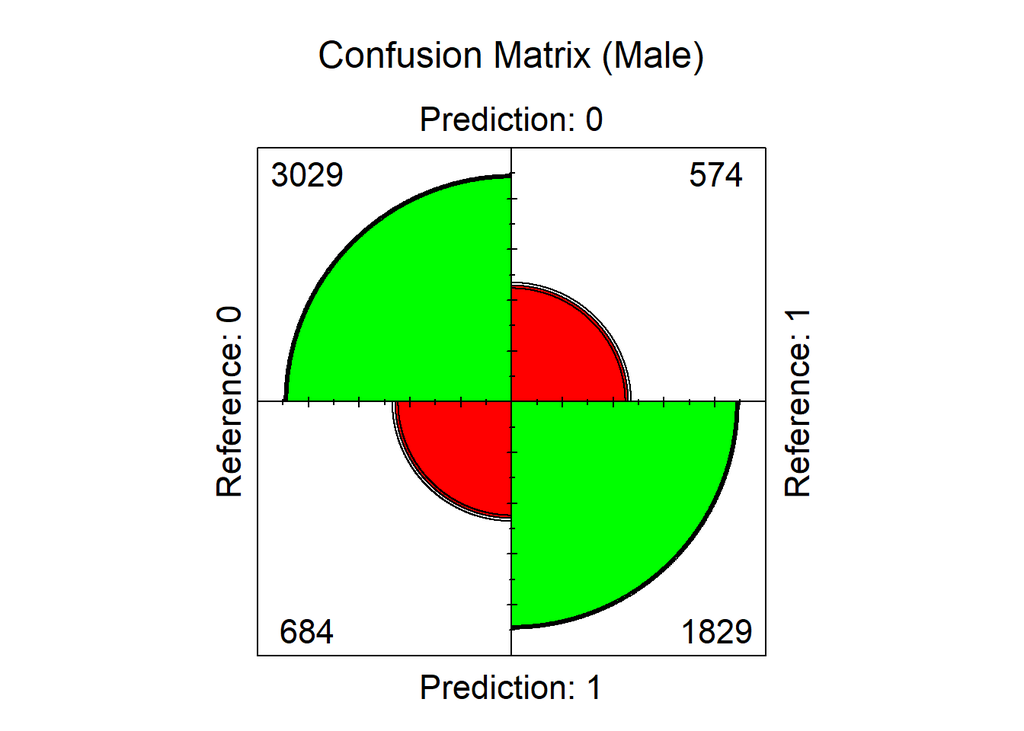

```r
cm_male <- confusionMatrix(as.factor(predicted_classes_male), as.factor(test_data_male$Podium))
fourfoldplot(cm_male$table, color = c("red", "green"), main = "Confusion Matrix (Male)")
```

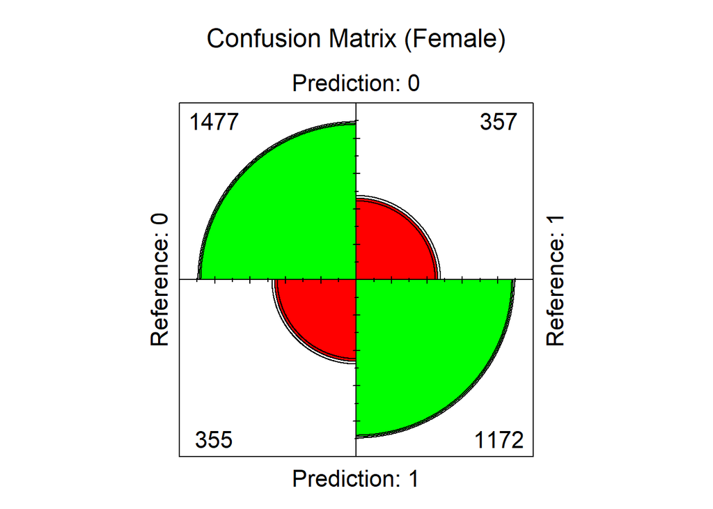

```r
cm_female <- confusionMatrix(as.factor(predicted_classes_female), as.factor(test_data_female$Podium))
fourfoldplot(cm_female$table, color = c("red", "green"), main = "Confusion Matrix (Female)")
```

### 7.2. ROC curves.

ROC curves are maximazed thanks to the threshold adjustment.

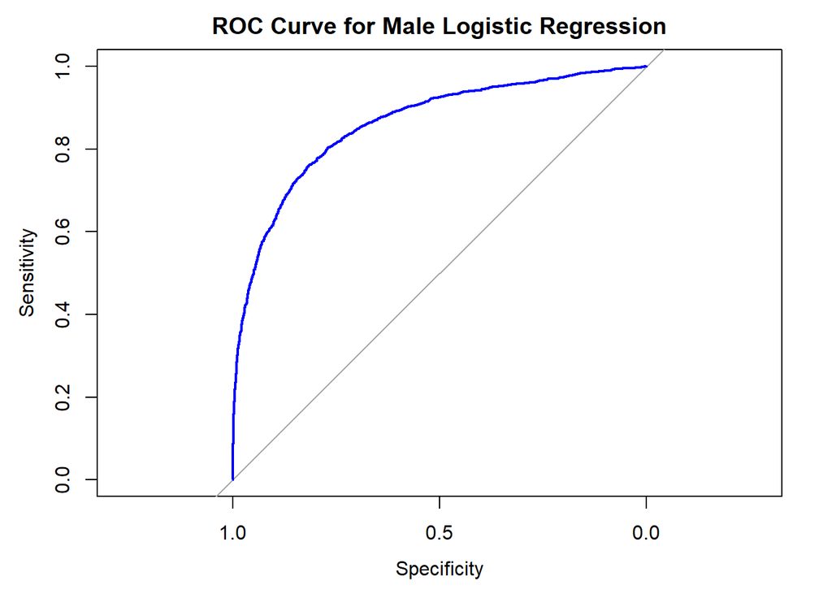

```r
roc_curve_male <- roc(test_data_male$Podium, predictions_male)
plot(roc_curve_male, col = "blue", main = "ROC Curve for Male Logistic Regression")
```

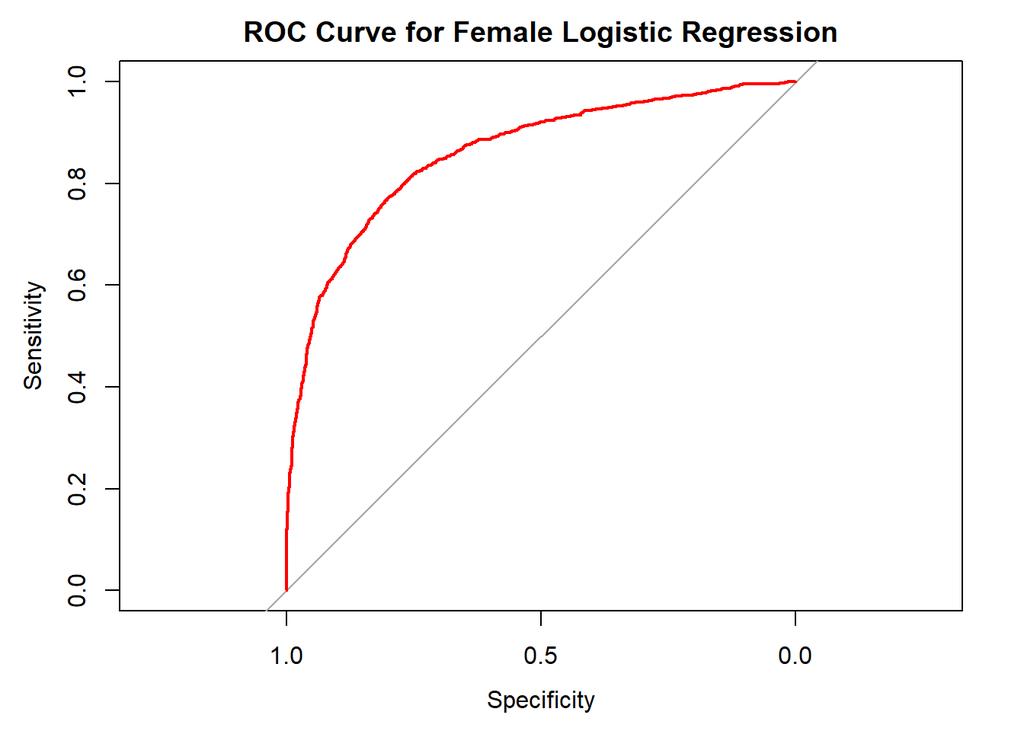

```r
roc_curve_female <- roc(test_data_female$Podium, predictions_female)
plot(roc_curve_female, col = "red", main = "ROC Curve for Female Logistic Regression")
```

### 7.3. Precision-Recall curves.

In the Precision-Recall test, male data in the AUC performs at 82,3% and the female data at 85,1%. These results are very good and add evidence that the model performs accurately enough to be considered reliable.

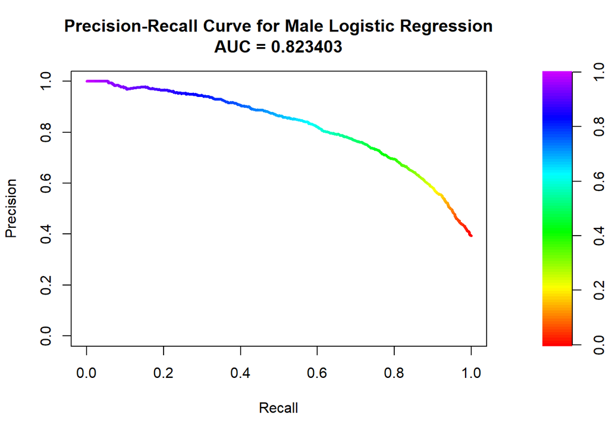

```r
logistic_regression_pr_male <- pr.curve(scores.class0 = predictions_male, weights.class0 = test_data_male$Podium, curve = TRUE)
plot(logistic_regression_pr_male, main = "Precision-Recall Curve for Male Logistic Regression")
```

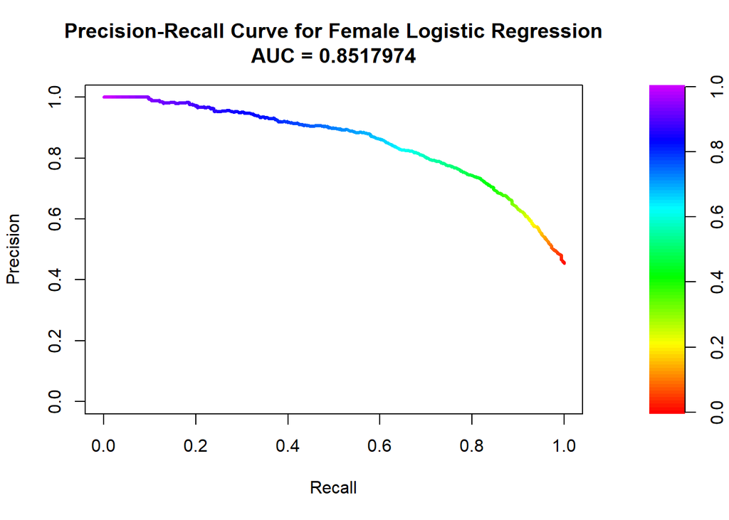

```r
logistic_regression_pr_female <- pr.curve(scores.class0 = predictions_female, weights.class0 = test_data_female$Podium, curve = TRUE)
plot(logistic_regression_pr_female, main = "Precision-Recall Curve for Female Logistic Regression")
```

# 8. Coefficients of Feature Importance by Movement Specialty

Now, it is time to find how relevant are some of the features in the model to reach the podium. First, movement specialties and their combinations.

**Balanced athletes (Balanced Specialist)**, **Squat Specialists** and **Bench Specialists** have positive coefficients with strong statistical significance, which means they are more likely to reach the podium. What is interesting is that **Deadlift Specialists** have negative coefficients, although with weak significance in the case of male data and no significance at all in the female data. **Squat and Bench Specialists** have higher coefficients and strong significance, while combinations with the **Deadlift** have no statistical significance, except for the weak significance levels for the **Bench & Deadlift Specialists** in the female data.

In practical terms, what this means is that being a **Deadlift Specialist** is likely not going to give the athlete an advantage to reach the podium. If so, it will decrease the odds to get into the podium. The other **movement specialties** add possibilities to the athletes to reach the podium.

```r
# 8.1. Coefficients by movement.

male_coeffs <- c(
  SquatSpecialist = 0.4009138,
  BenchSpecialist = 0.5795760,
  DeadliftSpecialist = -0.3380272,
  BalancedSpecialist = 0.3973726
)

female_coeffs <- c(
  SquatSpecialist = 0.5847690,
  BenchSpecialist = 0.9696019,
  DeadliftSpecialist = -0.3186478,
  BalancedSpecialist = 0.6267206
)


# 8.2. Standard errors by movement.

male_standard_errors <- c(
  SquatSpecialist = 1.803e-01,
  BenchSpecialist = 1.830e-01,
  DeadliftSpecialist = 1.838e-01,
  BalancedSpecialist = 1.843e-01
)

female_standard_errors <- c(
  SquatSpecialist = 2.730e-01,
  BenchSpecialist = 2.773e-01,
  DeadliftSpecialist = 2.752e-01,
  BalancedSpecialist = 2.776e-01
)


# 8.3. Calculating variances using standard errors.

male_variances <- male_standard_errors^2
female_variances <- female_standard_errors^2

# 8.4. Combined coefficients for two movement specialists.

male_combined <- c(
  SquatBench = male_coeffs["SquatSpecialist"] + male_coeffs["BenchSpecialist"],
  SquatDeadlift = male_coeffs["SquatSpecialist"] + male_coeffs["DeadliftSpecialist"],
  BenchDeadlift = male_coeffs["BenchSpecialist"] + male_coeffs["DeadliftSpecialist"]
)

female_combined <- c(
  SquatBench = female_coeffs["SquatSpecialist"] + female_coeffs["BenchSpecialist"],
  SquatDeadlift = female_coeffs["SquatSpecialist"] + female_coeffs["DeadliftSpecialist"],
  BenchDeadlift = female_coeffs["BenchSpecialist"] + female_coeffs["DeadliftSpecialist"]
)


# 8.5. Combined variances for two movement specialists.

male_combined_variances <- c(
  SquatBench = male_variances["SquatSpecialist"] + male_variances["BenchSpecialist"],
  SquatDeadlift = male_variances["SquatSpecialist"] + male_variances["DeadliftSpecialist"],
  BenchDeadlift = male_variances["BenchSpecialist"] + male_variances["DeadliftSpecialist"]
)

female_combined_variances <- c(
  SquatBench = female_variances["SquatSpecialist"] + female_variances["BenchSpecialist"],
  SquatDeadlift = female_variances["SquatSpecialist"] + female_variances["DeadliftSpecialist"],
  BenchDeadlift = female_variances["BenchSpecialist"] + female_variances["DeadliftSpecialist"]
)


# 8.6. Calculate p-values for two movement specialists.

male_combined_pvalues <- pnorm(abs(male_combined / sqrt(male_combined_variances)), lower.tail = FALSE) * 2
female_combined_pvalues <- pnorm(abs(female_combined / sqrt(female_combined_variances)), lower.tail = FALSE) * 2


# 8.7. Calculate p-values for one movement specialists.

male_pvalues <- pnorm(abs(male_coeffs / sqrt(male_variances)), lower.tail = FALSE) * 2
female_pvalues <- pnorm(abs(female_coeffs / sqrt(female_variances)), lower.tail = FALSE) * 2


# 8.9. Renaming variables to avoid bugs on table.

names(male_combined) <- c("SquatBench", "SquatDeadlift", "BenchDeadlift")
names(female_combined) <- c("SquatBench", "SquatDeadlift", "BenchDeadlift")
names(male_combined_variances) <- c("SquatBench", "SquatDeadlift", "BenchDeadlift")
names(female_combined_variances) <- c("SquatBench", "SquatDeadlift", "BenchDeadlift")
names(male_combined_pvalues) <- names(male_combined)
names(female_combined_pvalues) <- names(female_combined)


# 8.10. Summary of coefficients and p values by movement specialty.

summary_table <- data.frame(
  Specialist_Type = c(
    "Balanced Specialist",
    "Squat Specialist",
    "Bench Specialist",
    "Deadlift Specialist",
    "Squat & Bench Specialist",
    "Squat & Deadlift Specialist",
    "Bench & Deadlift Specialist"
  ),
  Male_Coefficients = c(
    male_coeffs["BalancedSpecialist"],
    male_coeffs["SquatSpecialist"],
    male_coeffs["BenchSpecialist"],
    male_coeffs["DeadliftSpecialist"],
    male_combined["SquatBench"],
    male_combined["SquatDeadlift"],
    male_combined["BenchDeadlift"]
  ),
  Male_pvalues = c(
    male_pvalues["BalancedSpecialist"],
    male_pvalues["SquatSpecialist"],
    male_pvalues["BenchSpecialist"],
    male_pvalues["DeadliftSpecialist"],
    male_combined_pvalues["SquatBench"],
    male_combined_pvalues["SquatDeadlift"],
    male_combined_pvalues["BenchDeadlift"]
  ),
  Female_Coefficients = c(
    female_coeffs["BalancedSpecialist"],
    female_coeffs["SquatSpecialist"],
    female_coeffs["BenchSpecialist"],
    female_coeffs["DeadliftSpecialist"],
    female_combined["SquatBench"],
    female_combined["SquatDeadlift"],
    female_combined["BenchDeadlift"]
  ),
  Female_pvalues = c(
    female_pvalues["BalancedSpecialist"],
    female_pvalues["SquatSpecialist"],
    female_pvalues["BenchSpecialist"],
    female_pvalues["DeadliftSpecialist"],
    female_combined_pvalues["SquatBench"],
    female_combined_pvalues["SquatDeadlift"],
    female_combined_pvalues["BenchDeadlift"]
  )
)

print(summary_table)
```

```
##                                Specialist_Type Male_Coefficients Male_pvalues
## BalancedSpecialist         Balanced Specialist         0.3973726 0.0310744300
## SquatSpecialist               Squat Specialist         0.4009138 0.0261758466
## BenchSpecialist               Bench Specialist         0.5795760 0.0015397691
## DeadliftSpecialist         Deadlift Specialist        -0.3380272 0.0658999830
## SquatBench            Squat & Bench Specialist         0.9804898 0.0001352838
## SquatDeadlift      Squat & Deadlift Specialist         0.0628866 0.8070381646
## BenchDeadlift      Bench & Deadlift Specialist         0.2415488 0.3516984916
##                    Female_Coefficients Female_pvalues
## BalancedSpecialist           0.6267206   2.396817e-02
## SquatSpecialist              0.5847690   3.219260e-02
## BenchSpecialist              0.9696019   4.712615e-04
## DeadliftSpecialist          -0.3186478   2.469142e-01
## SquatBench                   1.5543709   6.484487e-05
## SquatDeadlift                0.2661212   4.923865e-01
## BenchDeadlift                0.6509541   9.567144e-02
```

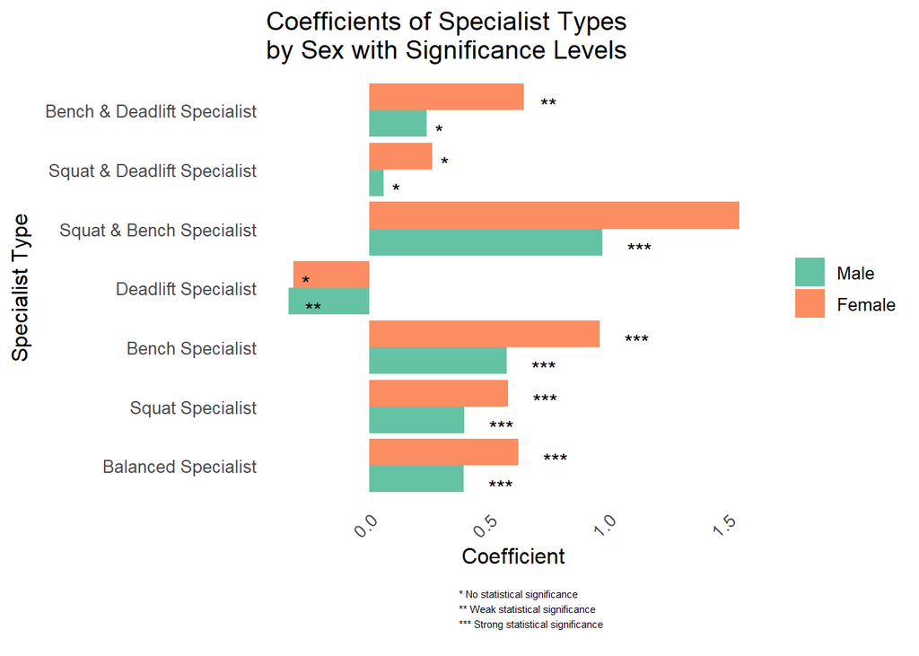

```r
# 8.11. Coefficients plot.


# 8.11.1. Specialist types ordered.

specialist_order <- c(
  "Balanced Specialist",
  "Squat Specialist",
  "Bench Specialist",
  "Deadlift Specialist",
  "Squat & Bench Specialist",
  "Squat & Deadlift Specialist",
  "Bench & Deadlift Specialist"
)

# 8.11.2. Melting and labeling.

summary_table_melted <- melt(
  summary_table[, c("Specialist_Type", "Male_Coefficients", "Female_Coefficients")],
  id.vars = "Specialist_Type",
  variable.name = "Sex",
  value.name = "Coefficient"
)


summary_table_melted$Sex <- recode(summary_table_melted$Sex,
                                   Male_Coefficients = "Male",
                                   Female_Coefficients = "Female")

# 8.11.3. Significance criteria.

summary_table_melted <- summary_table_melted %>%
  mutate(Significance = case_when(
    Sex == "Male" & summary_table$Male_pvalues < 0.05 ~ "***",
    Sex == "Male" & summary_table$Male_pvalues < 0.1 ~ "**",
    Sex == "Female" & summary_table$Female_pvalues < 0.05 ~ "***",
    Sex == "Female" & summary_table$Female_pvalues < 0.1 ~ "**",
    TRUE ~ "*"
  ))


summary_table_melted$Specialist_Type <- factor(
  summary_table_melted$Specialist_Type,
  levels = specialist_order
)

# 8.11.4. Coefficients plot with significance criteria.

main_plot <- ggplot(summary_table_melted, aes(x = Specialist_Type, y = Coefficient, fill = Sex)) +
  geom_bar(stat = "identity", position = "dodge") +
  geom_text(aes(label = Significance),
            position = position_dodge(width = 0.9),
            vjust = 1,
            hjust = -1,
            size = 4,
            color = "black") +
  coord_flip() +
  scale_fill_brewer(palette = "Set2", name = "Sex") +
  theme_minimal(base_size = 12) +
  theme(
    panel.background = element_rect(fill = "white", color = NA),
    panel.grid = element_blank(),
    plot.background = element_rect(fill = "white", color = NA),
    axis.text.x = element_text(angle = 45, hjust = 1),
    legend.title = element_blank(),
    legend.position = "right"
  ) +
  labs(
    title = "Coefficients of Specialist Types \nby Sex with Significance Levels",
    x = "Specialist Type",
    y = "Coefficient",
    fill = "Sex"
  )


annotation_box <- ggplot() +
  annotate(
    "text", x = 0.5, y = 0.5,
    label = "* No statistical significance\n** Weak statistical significance\n*** Strong statistical significance",
    size = 2, hjust = 0
  ) +
  theme_void() +
  theme(
    plot.margin = margin(t = 0, r = 10, b = 10, l = 10)
  )

final_plot <- plot_grid(
  main_plot,
  annotation_box,
  ncol = 1,
  rel_heights = c(3, 0.4)
)

final_plot
```

# 9. Coefficients of Feature Importance by Best Attempt per Movement

Now, coefficients for the best attempts of each movement. Th results highly contrast the ones of the last graph.

- The **Squat** has positive coefficients, but only the male data has a strong significance level while the female data has no statistical significance.
- The **Bench Press** has a negative coefficient for the male and positive for the female, but none of them are statistically significant. Seems like the **Bench Press** does not increase probabilities to reach the podium.
- The **Deadlift** has positive coefficients for both male and female data. While it is true that **Squat** also has an almost identical coefficient to the **Deadlift** in the male data, the **Deadlift** in both male and female data has incredibly low p values, which are virtually 0.

In practice, the **Deadlift** is the most relevant movement in the sport to reach the podium. Performing well in this movement, despite *movement specialty*, will increase the odds of reaching the podium. For the male athletes, **Squat** is also incredibly important, but not for the female athletes.

```r
# 9.1. Coefficients by movement.

male_coeffs_1 <- c(
  Best3SquatKg = 3.324e-02,
  Best3BenchKg =  -4.981e-03,
  Best3DeadliftKg = 3.233e-02
)

female_coeffs_1 <- c(
  Best3SquatKg = 3.760e-02,
  Best3BenchKg =  2.141e-02,
  Best3DeadliftKg = 4.310e-02
)


# 9.2. Standard errors by movement.

male_standard_errors_1 <- c(
  Best3SquatKg = 3.306e-03,
  Best3BenchKg =  4.476e-03,
  Best3DeadliftKg = 1.332e-03
)

female_standard_errors_1 <- c(
  Best3SquatKg = 2.634e-02,
  Best3BenchKg =  4.643e-02,
  Best3DeadliftKg = 2.543e-03
)


# 9.3. Calculating variances using standard errors.

male_variances_1 <- male_standard_errors_1^2
female_variances_1 <- female_standard_errors_1^2

# 9.4. Calculate p-values for one movement specialists.

male_pvalues_1 <- pnorm(abs(male_coeffs_1 / sqrt(male_variances_1)), lower.tail = FALSE) * 2
female_pvalues_1 <- pnorm(abs(female_coeffs_1 / sqrt(female_variances_1)), lower.tail = FALSE) * 2


# 9.5. Summary of coefficients and p values by best attempt by movement.

summary_table_1 <- data.frame(
  Movement_Attempt = c(
    "Best Squat Attempt",
    "Best Bench Attempt",
    "Best Deadlift Attempt"
  ),
  Male_Coefficients_1 = c(
    male_coeffs_1["Best3SquatKg"],
    male_coeffs_1["Best3BenchKg"],
    male_coeffs_1["Best3DeadliftKg"]
  ),
  Male_pvalues_1 = c(
    male_pvalues_1["Best3SquatKg"],
    male_pvalues_1["Best3BenchKg"],
    male_pvalues_1["Best3DeadliftKg"]
  ),
  Female_Coefficients_1 = c(
    female_coeffs_1["Best3SquatKg"],
    female_coeffs_1["Best3BenchKg"],
    female_coeffs_1["Best3DeadliftKg"]
  ),
  Female_pvalues_1 = c(
    female_pvalues_1["Best3SquatKg"],
    female_pvalues_1["Best3BenchKg"],
    female_pvalues_1["Best3DeadliftKg"]
  )
)

print(summary_table_1)
```

```
##                      Movement_Attempt Male_Coefficients_1 Male_pvalues_1
## Best3SquatKg       Best Squat Attempt            0.033240   8.781354e-24
## Best3BenchKg       Best Bench Attempt           -0.004981   2.657840e-01
## Best3DeadliftKg Best Deadlift Attempt            0.032330  3.895468e-130
##                 Female_Coefficients_1 Female_pvalues_1
## Best3SquatKg                  0.03760     1.534397e-01
## Best3BenchKg                  0.02141     6.447094e-01
## Best3DeadliftKg               0.04310     1.974737e-64
```

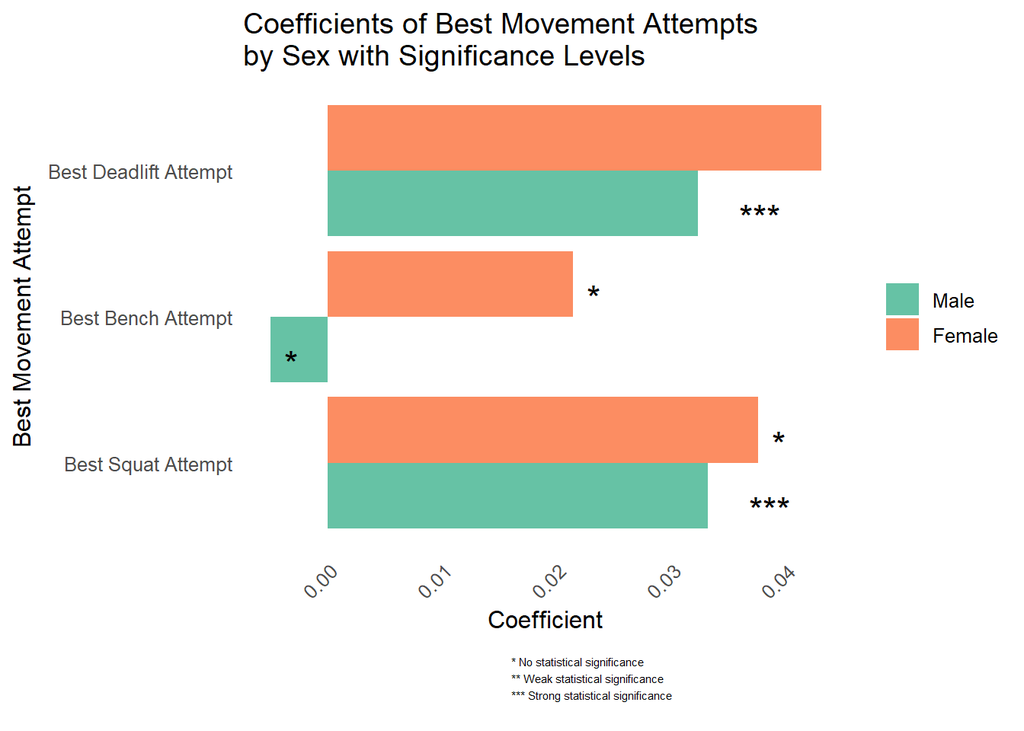

```r
# 9.6. Coefficients plot.

# 9.6.1. Specialist types ordered.

movement_attempt_order <- c(
  "Best Squat Attempt",
  "Best Bench Attempt",
  "Best Deadlift Attempt"
)

# 9.6.2. Melting and labeling.

summary_table_melted_1 <- melt(
  summary_table_1[, c("Movement_Attempt", "Male_Coefficients_1", "Female_Coefficients_1")],
  id.vars = "Movement_Attempt",
  variable.name = "Sex",
  value.name = "Coefficient"
)


summary_table_melted_1$Sex <- recode(summary_table_melted_1$Sex,
                                   Male_Coefficients_1 = "Male",
                                   Female_Coefficients_1 = "Female")

# 9.6.3. Significance criteria.

summary_table_melted_1 <- summary_table_melted_1 %>%
  mutate(PValue = case_when(
    Sex == "Male" ~ summary_table_1$Male_pvalues_1[match(Movement_Attempt, summary_table_1$Movement_Attempt)],
    Sex == "Female" ~ summary_table_1$Female_pvalues_1[match(Movement_Attempt, summary_table_1$Movement_Attempt)]
  ))

summary_table_melted_1 <- summary_table_melted_1 %>%
  mutate(Significance = case_when(
    PValue < 0.05 ~ "***",
    PValue < 0.1 ~ "**",
    TRUE ~ "*"
  ))

summary_table_melted_1$Movement_Attempt <- factor(
  summary_table_melted_1$Movement_Attempt,
  levels = movement_attempt_order
)

# 9.6.4. Coefficients plot with significance criteria.

main_plot_1 <- ggplot(summary_table_melted_1, aes(x = Movement_Attempt, y = Coefficient, fill = Sex)) +
  geom_bar(stat = "identity", position = "dodge") +
  geom_text(aes(label = Significance),
            position = position_dodge(width = 0.9),
            vjust = 1,
            hjust = -1,
            size = 6,
            color = "black") +
  coord_flip() +
  scale_fill_brewer(palette = "Set2", name = "Sex") +
  theme_minimal(base_size = 12) +
  theme(
    panel.background = element_rect(fill = "white", color = NA),
    panel.grid = element_blank(),
    plot.background = element_rect(fill = "white", color = NA),
    axis.text.x = element_text(angle = 45, hjust = 1),
    legend.title = element_blank(),
    legend.position = "right"
  ) +
  labs(
    title = "Coefficients of Best Movement Attempts \nby Sex with Significance Levels",
    x = "Best Movement Attempt",
    y = "Coefficient",
    fill = "Sex"
  )

annotation_box <- ggplot() +
  annotate(
    "text", x = 0.5, y = 0.5,
    label = "* No statistical significance\n** Weak statistical significance\n*** Strong statistical significance",
    size = 2, hjust = 0
  ) +
  theme_void() +
  theme(
    plot.margin = margin(t = 0, r = 10, b = 10, l = 10)
  )

final_plot_1 <- plot_grid(
  main_plot_1,
  annotation_box,
  ncol = 1,
  rel_heights = c(3, 0.4)
)

final_plot_1
```

# 6. Conclusions

**Movement specialties** have a positive and significant impact to reach the podium, except for the **Deadlift Specialists** and its combinations with others. In the Proportions Model, balanced athletes represented the majority, both overall and reaching the podium, but **Squat and/or Bench Specialists** do also make it into the podiums.

When it comes to movements themselves, **Deadlift** seems incredibly relevant for both male and female. The **Squat** is also relevant, but just for the male athletes. But why is that these movements are so important? The **Squat** and the **Deadlift** are the movements that add the highest amounts of weight lifted. The reason why these movements account for high amounts of the total weights lifted is because the muscles involved in the execution of those movements are some of the largest and strongest muscles in the human body. Mixed with optimal positions for the athletes, it explains why these movements add most of the total.

It seems like **biomechanics** has an effect in the performance of *Powerlifting* athletes that can be predicted using variables that are inherently affected by leverages of the human body.